# Markdown

Rodney Dyer, PhD

# Markdown

[figure not shown]

## Markdown Defines Typography

One of the challenges to producing several kinds of documents (e.g., HTML, DocX, PDF, Dashboard, etc.) from a single source is that the common WYSIWYG editors have you specify the physical appearance of elements.

- The font, color, and size of Headings.
- How to format titles and legends for tables and figures.
- How to number figures and tables.
- What is the base font.
- What is the page size.
- How do I get this image to not jump to the next f*%$ing page!!!

## Separation of Content from Display

What *Markdown* lets you

- Identify the components of the text that have special meaning, and then
- Defer decisions about styles, colors, fonts, etc. until render time.

In this presentation, the slide title is actually a level 2 heading and is shown on the slide as a **bold and larger** font face. However, if I rendered this as a single HTML page, it may be Orange but if it goes to a PowerPoint, I want it to fit into my color them and be **Red, bold, and Monospace**.

## Separation Leads to Simplicity

### 👎 Never

Waste your time working on display characteristics *before* the actual text of what you are producing is finished.

Your time is just too valuable.

### Instead 👍

Waste your time working on the actual content of the work you are doing.

The display will come later (reformatting bibliographies, changing journal formats, etc.)

## Separation Deferrs Internal Connections

Separating also allows you to generalize things like:

- References to figures and table and
- Bibliographies

What chaos is created by inserting a new figure in between Figure 3 and Figure 4 in your thesis written in Word?

## Separation Leads to Dynamic Documents

The use of Markdown mixed with `R` (or python or julia) means that we can:

1. Specify a table or figure in code
2. When rendered the actual figure of table is produced with the data.
3. Allows dynamic documents/reports to be created
4. Forms **tight** connection between the data, analyses, and associated textual descriptions

## Separation Leads to In-Text Content

Stop typing analyses and data output directly, have Markdown insert results when rendered.

- Use `R` code *within* the text itself.
- When the document is rendered, it will execute the code an put in the results into the text parts auto-magically (this is a *BFD*).
- Changes to data, analyses, df, test statistics, etc. are all integrated.

## Markdown is Text

Finally, since Markdown is just text:

- Allows the use of GitHub for repositories & collaboration,
- *Never* becomes lost because you cannot find a copy of some program that is no longer supported,
- Is always readable on all platforms at all times.

## Mardown is Text

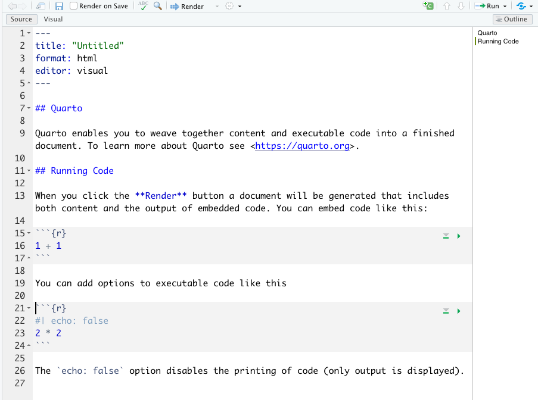

# YAML

## YAML

YAML (**Y**et **A**nother **M**arkdown **L**anguage) is a method of setting meta-data relevant to the parsing and rendering of a markdown document.

- It **must** be at the top of the document.
- It is *delimited* by three dashes, one set above and one below the content.
- Can be set for all files in a project (see file `_quarto.yml` in [this repository](https://github.com/dyerlabteaching/markdown)) to standardize meta data for all instances of a document type (e.g., all PDF’s have this them, all DOCX have a TOC, etc.).

## YAML Singleton Grammar

The way that YAML works is a simple key:value setup. For these cases, all items are on a single line, like you did previously to change the output from docx to html by changing:

`format: docx`

to

`format: html`

The colon is REQUIRED.

## YAML as Compound Stuff

Sometimes we have nested YAML. For example, maybe when I make a PDF I do not want a table of contents but when I create an html document I do. Instead of reformatting and rewriting all of this, I can include both PDF and HTML YAML.

To do this, you use tabs to nest items underneath the general section **and** add a colon to the end of each line that has some kind of nested object.

```
format:
  html:
    toc: true
  pdf:
    toc: false
```

## YAML with Several Options

And sometimes, we have a lot of options under a single *key* in YAML. For example, if we have several authors on a paper, we can include them as itemized entries.

```
author:
  - name: YOUR NAME
  - name: OTHER PERSON
```

## Your Turn 🫵

Try the following and see how it renders.

1. Open the quarto html document from before and add an option for the author by inserting `author: YOUR NAME HERE` into the YAML (n.b., you must replace `YOUR NAME HERE` with your actual name…)
2. Add three authors to the paper and render it.
3. Go check out the [quarto documentation](https://quarto.org/docs/journals/authors.html) on authors and affiliations and make an affiliation for each of the three authors.

# Markdown Syntax

## Simple Typographic Components

Markdown is a method to typeset *text* using only keyboard commands.

Plain text is displayed as body styled texts.

What you type is what you get.

## Titles, Sections, and Headings

In your word processor, you have Titles, Subtitles, Header 1, Header 2, Header 3, etc.

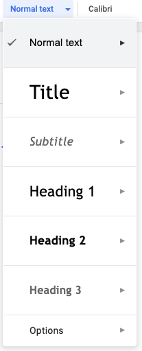

In Markdown, we indicate these elements by prepending a hashtag to the text.

## Titles, Sections, and Headings

The more hashtags, the less prominent the header level.

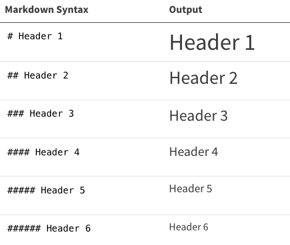

## Simple Typographic Markup

The most common features of text are also “marked them up” using the following conventions.

| Markdown | Result |
| --- | --- |
| *italic* | *italic* |
| **bold** | **bold** |
| ~~strikethrough~~ | strikethrough |

## Itemized & Numeric Lists

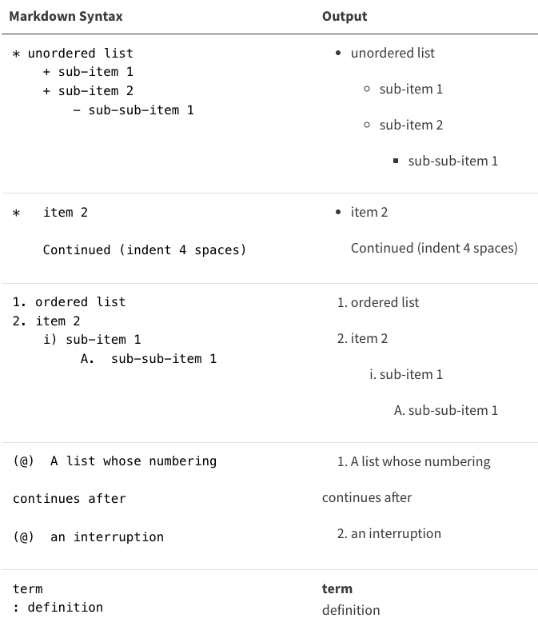

## Links & Local Images

URL’s can be used to include both to webpages and images (either online or as a path relative to the document you are making on the computer).

[output not shown]

Local references are *relative* to the markdown document.